# Estimating phylogenetic trees with phangorn

Klaus Schliep

Graz University of Technology  
klaus.schliep@gmail.com

2022-06-16

# Introduction

# Getting started

The first thing we have to do is to read in an alignment. Unfortunately there exists many different file formats that alignments can be stored in. The function `read.phyDat` is used to read in an alignment. There are several functions to read in alignments depending on the format of the data set (“nexus”, “phylip”, “fasta”) and the kind of data (amino acid or nucleotides) in the *ape* package (Paradis and Schliep 2019) and *phangorn*. The function `read.phyDat` calls these other functions and transform them into a `phyDat` object. For the specific parameter settings available look in the help files of the function `read.dna` (for phylip, fasta, clustal format), `read.nexus.data` for nexus files. For amino acid data additional `read.aa` is called.

We start our analysis loading the *phangorn* package and then reading in an alignment.

```r
library(ape)
library(phangorn)
fdir <- system.file("extdata/trees", package = "phangorn")
primates <- read.phyDat(file.path(fdir, "primates.dna"),
                        format = "interleaved")
```

# Distance based methods

After reading in the alignment we can build a first tree with distance based methods. The function dist.dna from the ape package computes distances for many DNA substitution models. To use the function dist.dna we have to transform the data to class DNAbin. For amino acids the function `dist.ml` offers common substitution models (for example “WAG”, “JTT”, “LG”, “Dayhoff”, “cpREV”, “mtmam”, “mtArt”, “MtZoa” or “mtREV24”).

After constructing a distance matrix we reconstruct a rooted tree with UPGMA and alternatively an unrooted tree using Neighbor Joining [Saitou and Nei (1987)](Studier and Keppler 1988). More distance methods like `fastme` are available in the *ape* package.

```r
dm  <- dist.ml(primates)
treeUPGMA  <- upgma(dm)
treeNJ  <- NJ(dm)
```

We can plot the trees treeUPGMA and treeNJ with the commands:

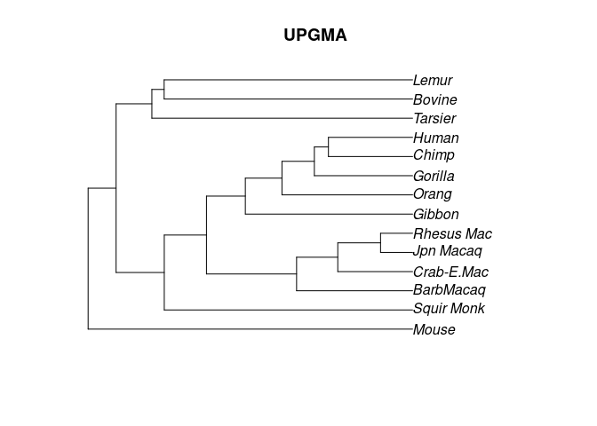

Rooted UPGMA tree.

```r
plot(treeUPGMA, main="UPGMA")
```

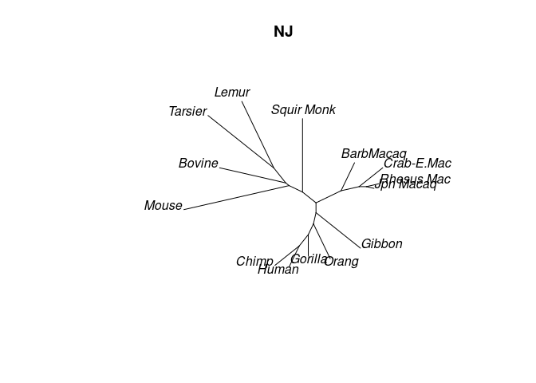

Unrooted NJ tree.

```r
plot(treeNJ, "unrooted", main="NJ")
```

## Bootstrap

To run the bootstrap we need to first write a function which computes a tree from an alignment. So we first need to compute a distance matrix and afterwards compute the tree. This function we can than give to the `bootstrap.phyDat` function.

```r
fun <- function(x) upgma(dist.ml(x))
bs_upgma <- bootstrap.phyDat(primates,  fun)
```

With the new syntax of R 4.1 this can be written a bit shorter:

```r
bs_upgma <- bootstrap.phyDat(primates,  \(x){dist.ml(x) |> upgma})
```

Finally we can plot the tree with bootstrap values added:

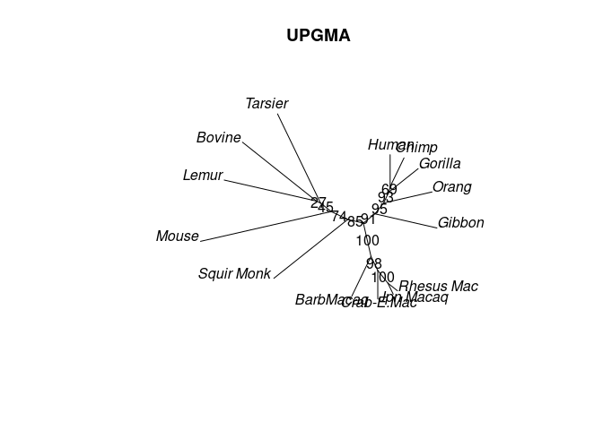

```r
plotBS(treeUPGMA, bs_upgma, main="UPGMA")
```

Distance based methods are very fast and we will use the UPGMA and NJ tree as starting trees for the maximum parsimony and maximum likelihood analyses.

# Parsimony

The function parsimony returns the parsimony score, that is the number of changes which are at least necessary to describe the data for a given tree. We can compare the parsimony score or the two trees we computed so far:

```r
parsimony(treeUPGMA, primates)
```

```
## [1] 751
```

```r
parsimony(treeNJ, primates)
```

```
## [1] 746
```

The function `optim.parsimony` performs tree rearrangements to find trees with a lower parsimony score. The tree rearrangement implemented are nearest-neighbor interchanges (NNI) and subtree pruning and regrafting (SPR). The later one only works so far with the fitch algorithm.

```r
treePars  <- optim.parsimony(treeUPGMA, primates)
```

```
## Final p-score 746 after  1 nni operations
```

However is also a version of the parsimony ratchet (Nixon 1999) implemented, which is likely to find better trees than just doing NNI / SPR rearrangements. The current implementation

1. Create a bootstrap data set $D_b$ from the original data set.
2. Take the current best tree and perform tree rearrangements on $D_b$ and save bootstrap tree as $T_b$.
3. Use $T_b$ and perform tree rearrangements on the original data set. If this trees has a lower parsimony score than the currently best tree replace it.
4. Iterate 1:3 until either a given number of iteration is reached or no improvements have been recorded for a number of iterations.

```r
treeRatchet  <- pratchet(primates, trace = 0)
parsimony(c(treePars, treeRatchet), primates)
```

```
## [1] 746 746
```

Next we assign branch length to the tree. The branch length are proportional to the number of substitutions / site.

```r
treeRatchet  <- acctran(treeRatchet, primates)
```

The parsimony ratchet implicitly performs a bootstrap analysis (step 1). We make use of this and store the trees which where visited. This allows us to add bootstrap support values to the tree.

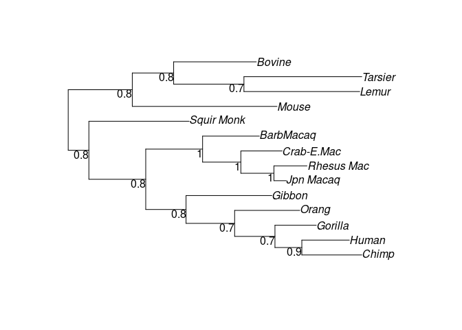

```r
plotBS(midpoint(treeRatchet), type="phylogram")
```

## Branch and bound

For data sets with few species it is also possible to find all most parsimonious trees using a branch and bound algorithm (Hendy and Penny 1982). For data sets with more than 10 taxa this can take a long time and depends strongly on how tree like the data are. And for more than 20-30 taxa this will take almost forever.

```r
(trees <- bab(subset(primates,1:10)))
```

```
## 1 phylogenetic tree
```

# Maximum likelihood

The last method we will describe in this vignette is Maximum Likelihood (ML) as introduced by Felsenstein (Felsenstein 1981). We can easily compute the likelihood for a tree given the data

```r
fit <- pml(treeNJ, data=primates)
fit
```

```
##
## model: JC
##
## loglikelihood: -3075
##
## unconstrained loglikelihood: -1230
##
## Rate matrix:
##   a c g t
## a 0 1 1 1
## c 1 0 1 1
## g 1 1 0 1
## t 1 1 1 0
##
## Base frequencies:
## 0.25 0.25 0.25 0.25
```

The function `pml` returns an object of class `pml`. This object contains the data, the tree and many different parameters of the model like the likelihood. There are many generic functions for the class `pml` available, which allow the handling of these objects.

```r
methods(class="pml")
```

```
## [1] AICc   BIC    anova  logLik plot   print  simSeq update vcov
## see '?methods' for accessing help and source code
```

The object fit just estimated the likelihood for the tree it got supplied, but the branch length are not optimized for the Jukes-Cantor model yet, which can be done with the function `optim.pml`.

```r
fitJC  <- optim.pml(fit, rearrangement="NNI")
```

```
## optimize edge weights:  -3075 --> -3068
## optimize edge weights:  -3068 --> -3068
##  optimize topology:  -3068 --> -3068
##  NNI moves:  1
##  optimize topology:  -3068 --> -3068
##  NNI moves:  0
## NNI moves:  1
## optimize edge weights:  -3068 --> -3068
##  optimize topology:  -3068 --> -3068
##  NNI moves:  0
## NNI moves:  0
```

```r
logLik(fitJC)
```

```
## 'log Lik.' -3068 (df=25)
```

With the default values`pml` will estimate a Jukes-Cantor model. The generic function `update` allows to change parameters. We will change the model to the GTR + $\Gamma(4)$ + I model and then optimize all the parameters.

```r
fitGTR <- update(fit, k=4, inv=0.2)
fitGTR <- optim.pml(fitGTR, model="GTR", optInv=TRUE, optGamma=TRUE,
    rearrangement = "NNI", control = pml.control(trace = 0))
fitGTR
```

```
##
## model: GTR+G(4)+I
##
## loglikelihood: -2609
##
## unconstrained loglikelihood: -1230
## Proportion of invariant sites: 0.005674
## Discrete gamma model
## Number of rate categories: 4
## Shape parameter: 2.989
##
## Rate matrix:
##         a         c         g       t
## a  0.0000  0.613751 35.926802  0.3748
## c  0.6138  0.000000  0.005558 15.0831
## g 35.9268  0.005558  0.000000  1.0000
## t  0.3748 15.083056  1.000000  0.0000
##
## Base frequencies:
## 0.3934 0.3791 0.04024 0.1873
```

With the control parameters the thresholds for the fitting process can be changed. Here we want just to suppress output during the fitting process. For larger trees the NNI rearrangements often get stuck in a local maximum. We added two stochastic algorithms to improve topology search. The first (set `rearrangement="stochastic"`) performs stochastic rearrangements similar as in (Nguyen et al. 2015), which makes random NNI permutation to the tree, which than gets optimized to escape local optima. The second option (rearrangement=“ratchet”) perform the likelihood ratchet (Vos 2003).

While these algorithms may find better trees they will also take more time.

```r
fitGTR <- optim.pml(fitGTR, model="GTR", optInv=TRUE, optGamma=TRUE,
    rearrangement = "stochastic", control = pml.control(trace = 0))
fitGTR
```

```
##
## model: GTR+G(4)+I
##
## loglikelihood: -2607
##
## unconstrained loglikelihood: -1230
## Proportion of invariant sites: 0.005565
## Discrete gamma model
## Number of rate categories: 4
## Shape parameter: 2.65
##
## Rate matrix:
##         a         c         g       t
## a  0.0000  0.946763 83.505056  0.6435
## c  0.9468  0.000000  0.004268 32.1269
## g 83.5051  0.004268  0.000000  1.0000
## t  0.6435 32.126883  1.000000  0.0000
##
## Base frequencies:
## 0.3964 0.3788 0.04026 0.1846
```

## Model selection

We can compare nested models for the JC and GTR + $\Gamma(4)$ + I model using likelihood ratio statistic

```r
anova(fitJC, fitGTR)
```

```
## Likelihood Ratio Test Table
##   Log lik. Df Df change Diff log lik. Pr(>|Chi|)
## 1    -3068 25
## 2    -2607 35        10           922     <2e-16 ***
## ---
## Signif. codes:  0 '***' 0.001 '**' 0.01 '*' 0.05 '.' 0.1 ' ' 1
```

with the Shimodaira-Hasegawa test

```r
SH.test(fitGTR, fitJC)
```

```
##      Trees  ln L Diff ln L p-value
## [1,]     1 -2607       0.0   0.499
## [2,]     2 -3068     461.2   0.000
```

or with the AIC

```r
AIC(fitJC)
```

```
## [1] 6187
```

```r
AIC(fitGTR)
```

```
## [1] 5284
```

```r
AICc(fitGTR)
```

```
## [1] 5297
```

```r
BIC(fitGTR)
```

```
## [1] 5405
```

An alternative is to use the function `modelTest` to compare different nucleotide or protein models the AIC, AICc or BIC, similar to popular programs ModelTest and ProtTest (D. Posada and Crandall 1998), (David Posada 2008), (Abascal, Zardoya, and Posada 2005). By default available nucleotide or amino acid models available are compared.

```r
mt <- modelTest(primates)
```

Here we can select only some common models:

```r
mt <- modelTest(primates, model=c("JC", "F81", "K80", "HKY", "SYM", "GTR"))
```

The results of `modelTest` is illustrated in following table:

| Model | df | logLik | AIC | AICw | AICc | AICcw | BIC |
| --- | --- | --- | --- | --- | --- | --- | --- |
| JC | 25 | -3068 | 6187 | 0.00 | 6193 | 0.00 | 6273 |
| JC+I | 26 | -3063 | 6177 | 0.00 | 6184 | 0.00 | 6267 |
| JC+G | 26 | -3067 | 6186 | 0.00 | 6193 | 0.00 | 6275 |
| JC+G+I | 27 | -3063 | 6179 | 0.00 | 6187 | 0.00 | 6272 |
| F81 | 28 | -2918 | 5892 | 0.00 | 5900 | 0.00 | 5989 |
| F81+I | 29 | -2909 | 5876 | 0.00 | 5885 | 0.00 | 5976 |
| F81+G | 29 | -2913 | 5883 | 0.00 | 5892 | 0.00 | 5983 |
| F81+G+I | 30 | -2909 | 5877 | 0.00 | 5886 | 0.00 | 5980 |
| K80 | 26 | -2953 | 5958 | 0.00 | 5965 | 0.00 | 6048 |
| K80+I | 27 | -2945 | 5943 | 0.00 | 5950 | 0.00 | 6036 |
| K80+G | 27 | -2945 | 5944 | 0.00 | 5951 | 0.00 | 6037 |
| K80+G+I | 28 | -2942 | 5941 | 0.00 | 5949 | 0.00 | 6037 |
| HKY | 29 | -2625 | 5308 | 0.00 | 5317 | 0.00 | 5408 |
| HKY+I | 30 | -2621 | 5303 | 0.00 | 5312 | 0.00 | 5406 |
| HKY+G | 30 | -2613 | 5285 | 0.18 | 5295 | 0.45 | 5389 |
| HKY+G+I | 31 | -2612 | 5287 | 0.08 | 5297 | 0.14 | 5394 |
| SYM | 30 | -2814 | 5688 | 0.00 | 5697 | 0.00 | 5791 |
| SYM+I | 31 | -2812 | 5685 | 0.00 | 5695 | 0.00 | 5792 |
| SYM+G | 31 | -2805 | 5671 | 0.00 | 5681 | 0.00 | 5778 |
| SYM+G+I | 32 | -2805 | 5673 | 0.00 | 5684 | 0.00 | 5784 |
| GTR | 33 | -2619 | 5303 | 0.00 | 5315 | 0.00 | 5417 |
| GTR+I | 34 | -2614 | 5295 | 0.00 | 5307 | 0.00 | 5412 |
| GTR+G | 34 | -2608 | 5283 | 0.47 | 5295 | 0.29 | 5401 |
| GTR+G+I | 35 | -2607 | 5284 | 0.27 | 5297 | 0.11 | 5405 |

The thresholds for the optimization in `modelTest` are not as strict as for `optim.pml` and no tree rearrangements are performed. As `modelTest` computes and optimizes a lot of models it would be a waste of computer time not to save these results. The results are saved as call together with the optimized trees in an environment and the function `as.pml` evaluates this call to get a `pml` object back to use for further optimization or analysis.

```r
(fit <- as.pml(mt, "HKY+G+I"))
```

```
##
## model: HKY+G(4)+I
##
## loglikelihood: -2612
##
## unconstrained loglikelihood: -1230
## Proportion of invariant sites: 0.002734
## Discrete gamma model
## Number of rate categories: 4
## Shape parameter: 2.127
##
## Rate matrix:
##       a     c     g     t
## a  0.00  1.00 56.03  1.00
## c  1.00  0.00  1.00 56.03
## g 56.03  1.00  0.00  1.00
## t  1.00 56.03  1.00  0.00
##
## Base frequencies:
## 0.4205 0.3623 0.04394 0.1733
```

```r
(fit <- as.pml(mt, "BIC"))
```

```
##
## model: HKY+G(4)
##
## loglikelihood: -2613
##
## unconstrained loglikelihood: -1230
## Discrete gamma model
## Number of rate categories: 4
## Shape parameter: 2.145
##
## Rate matrix:
##       a     c     g     t
## a  0.00  1.00 51.44  1.00
## c  1.00  0.00  1.00 51.44
## g 51.44  1.00  0.00  1.00
## t  1.00 51.44  1.00  0.00
##
## Base frequencies:
## 0.4193 0.3629 0.04389 0.1739
```

## Bootstrap

At last we may want to apply bootstrap to test how well the edges of the tree are supported:

```r
bs <- bootstrap.pml(fitJC, bs=100, optNni=TRUE,
    control = pml.control(trace = 0))
```

Now we can plot the tree with the bootstrap support values on the edges and also look at `consensusNet` to identify potential conflict.

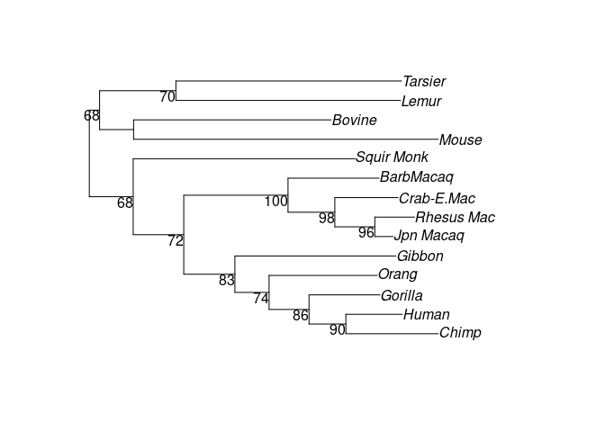

Tree with bootstrap support. Unrooted tree (midpoint rooted) with bootstrap support values.

```r
plotBS(midpoint(fitJC$tree), bs, p = 50, type="p")
```

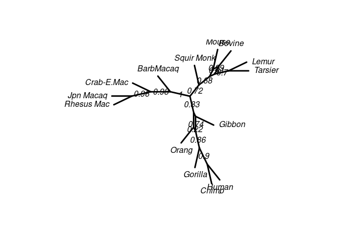

ConsensusNet from the bootstrap sample.

```r
cnet <- consensusNet(bs, p=0.2)
plot(cnet, show.edge.label=TRUE)
```

## Molecular dating with a strict clock

```r
fit_strict <- pml(treeUPGMA, data=primates, k=4, bf=baseFreq(primates))
fit_strict <- optim.pml(fit_strict, model="GTR", optRooted = TRUE,
                        rearrangement = "NNI", optGamma = TRUE, optInv = TRUE,
                        control = pml.control(trace = 0))
```

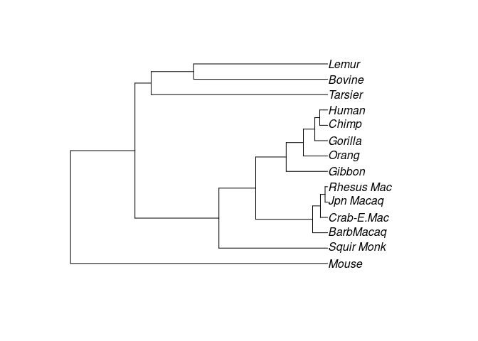

```r
plot(fit_strict)
```

Several analyses, e.g.`bootstrap` and `modelTest`, can be computationally demanding, but as nowadays most computers have several cores one can distribute the computations using the *parallel* package. However it is only possible to use this approach if R is running from command line (“X11”), but not using a GUI (for example “Aqua” on Macs) and unfortunately the *parallel* package does not work at all under Windows.

# Appendix

## Standard scripts for nucleotide analysis

Here we provide two standard scripts which can be adapted for the most common tasks. Most likely the arguments for `read.phyDat` have to be adapted to accommodate your file format. Both scripts assume that the *parallel* package works on your platform, see comments above.

```r
library(phangorn)
file <- "myfile"
dat <- read.phyDat(file)
dm <- dist.ml(dat, "F81")
tree <- NJ(dm)
# as alternative for a starting tree:
tree <- pratchet(dat)          # parsimony tree
tree <- nnls.phylo(tree, dm)   # need edge weights


# 1. alternative: quick and dirty: GTR + G
fitStart <- pml(tree, dat, k=4)
fit <- optim.pml(fitStart, model="GTR", optGamma=TRUE, rearrangement="stochastic")

# 2. alternative: prepare with modelTest
mt <- modelTest(dat, tree=tree, multicore=TRUE)
mt[order(mt$AICc),]
# choose best model from the table according to AICc
fitStart <- as.pml(mt, "AICc")

# equivalent to:   fitStart = eval(get("GTR+G+I", env), env)
fit <- optim.pml(fitStart, rearrangement = "stochastic",
    optGamma=TRUE, optInv=TRUE, model="GTR")
bs <- bootstrap.pml(fit, bs=100, optNni=TRUE, multicore=TRUE)
```

## Standard scripts for amino acid analysis

You can specify different several models build in which you can specify, e.g. “WAG”, “JTT”, “Dayhoff”, “LG”. Optimizing the rate matrix for amino acids is possible, but would take a long, a very long time and you will need to have a large alignment to estimate all the parameters. So make sure to set `optBf=FALSE` and `optQ=FALSE` in the function `optim.pml`, which is also the default.

```r
library(phangorn)
file <- "myfile"
dat <- read.phyDat(file, type = "AA")
dm <- dist.ml(dat, model="JTT")
tree <- NJ(dm)

# parallel will only work safely from command line
# and not at all windows
(mt <- modelTest(dat, model=c("JTT", "LG", "WAG"),
    multicore=TRUE))
# run all available amino acid models
(mt <- modelTest(dat, model="all", multicore=TRUE))

fitStart <- as.pml(mt)

fitNJ <- pml(tree, dat, model="JTT", k=4, inv=.2)
fit <- optim.pml(fitNJ, rearrangement = "stochastic",
    optInv=TRUE, optGamma=TRUE)
fit

bs <- bootstrap.pml(fit, bs=100, optNni=TRUE, multicore=TRUE)
```

# References

Abascal, Federico, Rafael Zardoya, and David Posada. 2005. “ProtTest: Selection of Best-Fit Models of Protein Evolution.” *Bioinformatics* 21 (9): 2104–5. https://doi.org/10.1093/bioinformatics/bti263.

Felsenstein, Joseph. 1981. “Evolutionary Trees from DNA Sequences: A Maxumum Likelihood Approach.” *Journal of Molecular Evolution* 17: 368–76.

———. 2004. *Inferring Phylogenies*. Sunderland: Sinauer Associates.

Hendy, M. D., and D. Penny. 1982. “Branch and Bound Algorithms to Determine Minimal Evolutionary Trees.” *Math. Biosc.* 59: 277–90.

Nguyen, Lam-Tung, Heiko A. Schmidt, Arndt von Haeseler, and Bui Quang Minh. 2015. “IQ-TREE: A Fast and Effective Stochastic Algorithm for Estimating Maximum-Likelihood Phylogenies.” *Molecular Biology and Evolution* 32 (1): 268–74. https://doi.org/10.1093/molbev/msu300.

Nixon, K. 1999. “The Parsimony Ratchet, a New Method for Rapid Rarsimony Analysis.” *Cladistics* 15: 407–14.

Paradis, Emmanuel. 2012. *Analysis of Phylogenetics and Evolution with r*. Second. New York: Springer.

Paradis, Emmanuel, and Klaus Schliep. 2019. “Ape 5.0: An Environment for Modern Phylogenetics and Evolutionary Analyses in r.” *Bioinformatics* 35 (3): 526–28. https://doi.org/10.1093/bioinformatics/bty633.

Posada, David. 2008. “jModelTest: Phylogenetic Model Averaging.” *Molecular Biology and Evolution* 25 (7): 1253–56. https://doi.org/10.1093/molbev/msn083.

Posada, D., and K. A. Crandall. 1998. “MODELTEST: Testing the Model of DNA Substitution.” *Bioinformatics* 14 (9): 817–18.

Saitou, N., and M. Nei. 1987. “The Neighbor-Joining Method - a New Method for Reconstructing Phylogenetic Trees.” *Molecular Biology and Evolution* 4 (4): 406–25.

Schliep, Klaus Peter. 2011. “Phangorn: Phylogenetic Analysis in R.” *Bioinformatics* 27 (4): 592–93. https://doi.org/10.1093/bioinformatics/btq706.

Studier, J. A., and K. J. Keppler. 1988. “A Note on the Neighbor-Joining Algorithm of Saitou and Nei.” *Molecular Biology and Evolution* 5 (6): 729–31.

Vos, R. A. 2003. “Accelerated Likelihood Surface Exploration: The Likelihood Ratchet.” *Systematic Biology* 52 (3): 368–73.

Yang, Ziheng. 2006. *Computational Molecular Evolution*. Oxford: Oxford University Press.